# Single fit and overlay

h qin

June 9, July 6-11, 2017

20171002 Add AIC The log-likelihood values calculated by FlexSurv and my own routine return values with 10x differences. This is an old problem. see http://hongqinlab.blogspot.com/2014/07/compare-binomial-gompertz-and-weibull.html It seems FlexSurv used the loglikehood value from optim().

1. Major bug found. file names and strains names are inconsistent.

20160711-> Fitting RLS dataset merged by strains.

```r
rm(list=ls())
#setwd("~/github/0.network.aging.prj.bmc/0a.rls.fitting")
setwd("~/github/bmc_netwk_aging_manuscript/R1/0.nat.rls.fitting")
library('flexsurv')
source("../lifespan.r")
```

```r
##### log likelihood function, R-fixed 2-parameter binomial mortality rate model
# http://hongqinlab.blogspot.com/2013/12/binomial-mortailty-model.html
# m = R ( 1 + t/t0)^(n-1)
# s = exp( (R t0/n)*(1 - (1+t/t0)^n ) )

llh.binomialMortality.single.run.NoR0 <- function( Rt0n, lifespan, debug=0 ) {
  I = R0;
  t0 = Rt0n[2]; n=Rt0n[3];
  my.data = lifespan[!is.na(lifespan)];
  log_s = (I * t0 /n )*(1 - (1 + my.data/t0)^n);
  log_m = log(I) +  (n-1) * log(1 + my.data/t0 );
  my.lh = sum(log_s)  + sum(log_m);
  if(debug) { print (c(I, Rt0n )); } #trace the convergence
  ret = - my.lh # because optim seems to maximize
}


llh.binomialMortality.single.run.FixedN <- function( Rt0n, lifespan, debug=0 ) {
  I=Rt0n[1]; t0 = Rt0n[2]; #n=Rt0n[3]; n defined outside
  my.data = lifespan[!is.na(lifespan)];
  log_s = (I * t0 /n )*(1 - (1 + my.data/t0)^n);
  log_m = log(I) +  (n-1) * log(1 + my.data/t0 );
  my.lh = sum(log_s)  + sum(log_m);
  if(debug) { print (c(I, Rt0n )); } #trace the convergence
  ret = - my.lh # because optim seems to maximize
}
```

# Parse strains from files

```r
set.seed(20170101)
```

Take files from natural isolates

```r
my.strains=c("101S", "M1-2","M13","M14","M2-8","M22","M32","M34","M5","M8","RM112N","S288c","SGU57", "YPS128","YPS163")

report = data.frame(cbind(my.strains))
report$samplesize = NA; report$R=NA; report$t0=NA; report$n=NA; report$G=NA; report$longfilename=NA;
```

# Now, fit all RLS data sets by strains

```r
for( i in 1:length(report[,1])){
#for( i in 3:4){
  filename = paste("rls/", my.strains[i], ".csv", sep='' );
  report$longfilename[i] = filename;
  tb = read.csv( filename, header =F)

  report$samplesize[i] = length(tb[,1])

  GompFlex = flexsurvreg(formula = Surv(tb[,1]) ~ 1, dist = 'gompertz')
  WeibFlex = flexsurvreg(formula = Surv(tb[,1]) ~ 1, dist = 'weibull')

  report$avgLS[i] =  mean(tb[,1])
  report$stdLS[i] =  sd(tb[,1])
  report$CV[i] = report$stdLS[i] / report$avgLS[i]

  report$GompGFlex[i] = GompFlex$res[1,1]
  report$GompRFlex[i] = GompFlex$res[2,1]
  report$GompLogLikFlex[i] = round(GompFlex$loglik, 1)
  report$GompAICFlex[i] = round(GompFlex$AIC)

  report$WeibShapeFlex[i] = WeibFlex$res[1,1]
  report$WeibRateFlex[i] = WeibFlex$res[2,1]
  report$WeibLogLikFlex[i] = round(WeibFlex$loglik, 1)
  report$WeibAICFlex[i] = round(WeibFlex$AIC)

  #set initial values
  Rhat = report$GompRFlex[i]; # 'i' was missing. a bug costed HQ a whole afternoon.
  Ghat = report$GompGFlex[i];
  nhat = 8;
  t0= (nhat-1)/Ghat;

  if( is.na( match(my.strains[i], c('M8' )) ) ) {
    fitBinom = optim ( c(Rhat, t0, nhat),  llh.binomialMortality.single.run,
                       lifespan=tb[,1],
                       #method='SANN') #SANN needs control
                       method="L-BFGS-B",
                       lower=c(1E-4, 1, 2), upper=c(0.1,200,100) );
    report[i, c("R", "t0", "n")] = fitBinom$par[1:3]
    report$BinomialAIC[i] = 2*3 + 2*fitBinom$value
  } else { #M8, fix n
    print(my.strains[i])
    #llh.binomialMortality.single.run.FixedN <- function( Rt0n, lifespan, debug=0 ) {
    n=11.5;
    fitBinom = optim ( c(Rhat, t0, nhat),  llh.binomialMortality.single.run.FixedN,
                       lifespan=tb[,1],
                       #method='SANN') #SANN needs control
                       method="L-BFGS-B",
                       lower=c(1E-5, 1, 2), upper=c(0.1,200,100) );
    report[i, c("R", "t0", "n")] = c(fitBinom$par[1:2], n)
    report$BinomialAIC[i] = 2*3 + 2*fitBinom$value
  }
  report$G[i] = (report$n[i] - 1)/report$t0[i]

  #AIC
  # llh.binomialMortality.single.run <- function( Rt0n, lifespan, debug=0 )
  #report$BinomialAICqin[i] = 2*3 + 2*llh.binomialMortality.single.run( report[i, c("R", "t0", "n")], lifespan=tb[,1] )

  #llh.G.single.run <- function( IG, lifespan ) {
  #report$GompAICqin[i] = 2*2 + 2* llh.G.single.run(report[i,c("GompRFlex", "GompGFlex")], lifespan=tb[,1])
    # dgompertz <- function(x, shape, rate=1, log=FALSE)
  #report$GompAICdgompergtz[i] = 2*2 - 2* sum(dgompertz(tb[,1],shape=report$GompGFlex[i], rate=report$GompRFlex, log=TRUE));
  #report$GompAICdgompergtz2[i] = 2*2 - 2* sum(dgompertz(tb[,1],shape=report$GompRFlex[i], rate=report$GompGFlex, log=TRUE));

}
```

```
## [1] "M8"
```

Show the results

```r
#report[ grep("tBY", report$strains), ]
report
```

```
##    my.strains samplesize            R        t0         n          G
## 1        101S         85 0.0019760147  52.08681  9.174228 0.15693470
## 2        M1-2         54 0.0027664362  56.71641  9.475570 0.14943770
## 3         M13         70 0.0030071379  56.81672  9.648416 0.15221605
## 4         M14         60 0.0024869119  76.42752  9.180570 0.10703698
## 5        M2-8        105 0.0036633868  60.10209 10.068263 0.15088099
## 6         M22         60 0.0025096036  64.81929  9.400784 0.12960313
## 7         M32         60 0.0022090312  49.67204  9.556550 0.17226088
## 8         M34         58 0.0021231171  44.49124  8.940977 0.17848407
## 9          M5        166 0.0035875496 104.60572  9.903523 0.08511506
## 10         M8         60 0.0002276221  45.20362 11.500000 0.23228229
## 11     RM112N         59 0.0022367518  78.29925  8.184119 0.09175208
## 12      S288c         41 0.0053611878  80.43622  9.959994 0.11139252
## 13      SGU57         58 0.0067256427  78.02415  9.696555 0.11145978
## 14     YPS128         69 0.0024378049  58.96767  8.260993 0.12313514
```

[output cut: 49 more lines]

```r
summary(report[, c("avgLS", "t0", "n")])
```

```
##      avgLS             t0               n
##  Min.   :23.86   Min.   : 44.49   Min.   : 8.184
##  1st Qu.:26.78   1st Qu.: 52.16   1st Qu.: 9.058
##  Median :31.34   Median : 58.97   Median : 9.476
##  Mean   :31.27   Mean   : 63.93   Mean   : 9.426
##  3rd Qu.:34.97   3rd Qu.: 77.23   3rd Qu.: 9.800
##  Max.   :44.07   Max.   :104.61   Max.   :11.500
```

# Overlay the binomial aging model with observation.

see http://hongqinlab.blogspot.com/2013/12/binomial-mortailty-model.html m = R ( 1 + t/t0)^(n-1) s = exp( (R t0/n)*(1 - (1+t/t0)^n ) )

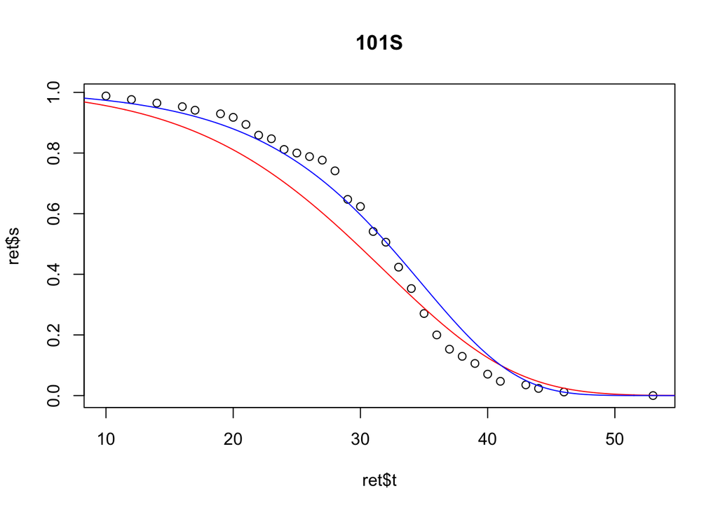

```
##   my.strains samplesize           R       t0        n         G
## 1       101S         85 0.001976015 52.08681 9.174228 0.1569347
##   longfilename    avgLS    stdLS        CV GompGFlex   GompRFlex
## 1 rls/101S.csv 31.34118 7.512772 0.2397093 0.1340729 0.001265456
##   GompLogLikFlex GompAICFlex WeibShapeFlex WeibRateFlex WeibLogLikFlex
## 1           -295         594      4.778139     34.15561           -291
##   WeibAICFlex BinomialAIC
## 1         586    601.3715
##             R       t0        n         G
## 1 0.001976015 52.08681 9.174228 0.1569347
```

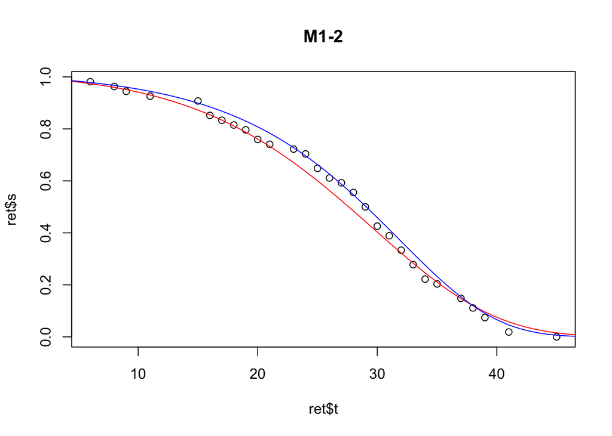

```
##   my.strains samplesize           R       t0       n         G
## 2       M1-2         54 0.002766436 56.71641 9.47557 0.1494377
##   longfilename    avgLS   stdLS        CV GompGFlex   GompRFlex
## 2 rls/M1-2.csv 27.83333 9.20162 0.3305971 0.1231034 0.002449421
##   GompLogLikFlex GompAICFlex WeibShapeFlex WeibRateFlex WeibLogLikFlex
## 2         -193.6         391      3.538533     30.92356         -195.6
##   WeibAICFlex BinomialAIC
## 2         395    394.9773
##             R       t0       n         G
## 2 0.002766436 56.71641 9.47557 0.1494377
```

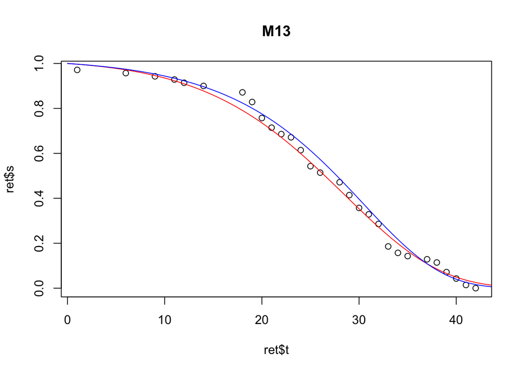

```
##   my.strains samplesize           R       t0        n         G
## 3        M13         70 0.003007138 56.81672 9.648416 0.1522161
##   longfilename    avgLS    stdLS        CV GompGFlex   GompRFlex
## 3  rls/M13.csv 26.54286 9.142488 0.3444425  0.122849 0.002926113
##   GompLogLikFlex GompAICFlex WeibShapeFlex WeibRateFlex WeibLogLikFlex
## 3         -250.1         504      3.114056     29.26548         -259.1
##   WeibAICFlex BinomialAIC
## 3         522    508.0275
##             R       t0        n         G
## 3 0.003007138 56.81672 9.648416 0.1522161
```

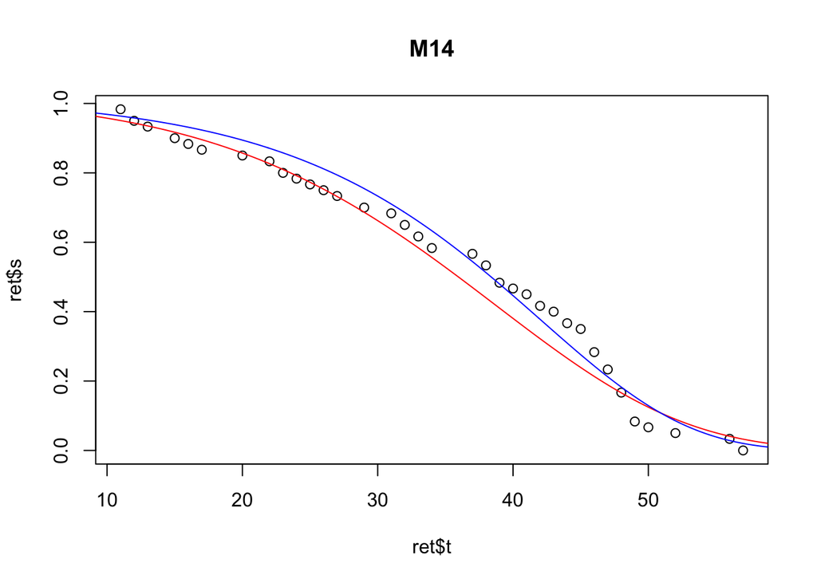

```
##   my.strains samplesize           R       t0       n        G longfilename
## 4        M14         60 0.002486912 76.42752 9.18057 0.107037  rls/M14.csv
##   avgLS    stdLS        CV  GompGFlex  GompRFlex GompLogLikFlex
## 4 36.55 12.80416 0.3503191 0.09148573 0.00195105         -233.7
##   GompAICFlex WeibShapeFlex WeibRateFlex WeibLogLikFlex WeibAICFlex
## 4         471      3.361407     40.80155         -236.8         478
##   BinomialAIC
## 4      476.73
##             R       t0       n        G
## 4 0.002486912 76.42752 9.18057 0.107037
```

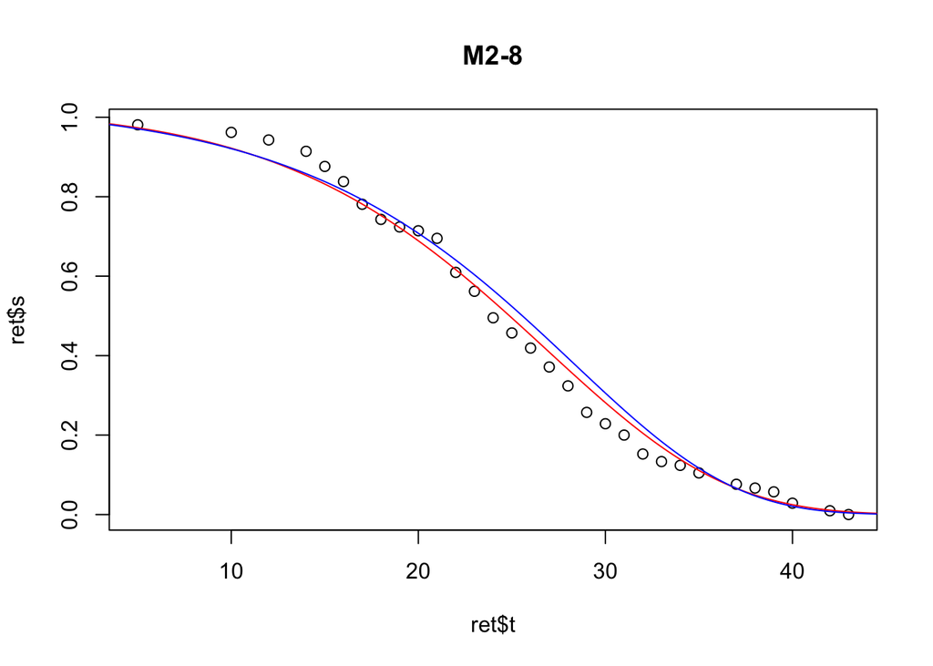

```
##   my.strains samplesize           R       t0        n        G
## 5       M2-8        105 0.003663387 60.10209 10.06826 0.150881
##   longfilename    avgLS    stdLS        CV GompGFlex   GompRFlex
## 5 rls/M2-8.csv 24.80952 8.133614 0.3278424 0.1160839 0.004361288
##   GompLogLikFlex GompAICFlex WeibShapeFlex WeibRateFlex WeibLogLikFlex
## 5         -373.3         751      3.371375     27.61417         -368.5
##   WeibAICFlex BinomialAIC
## 5         741    749.3801
##             R       t0        n        G
## 5 0.003663387 60.10209 10.06826 0.150881
```

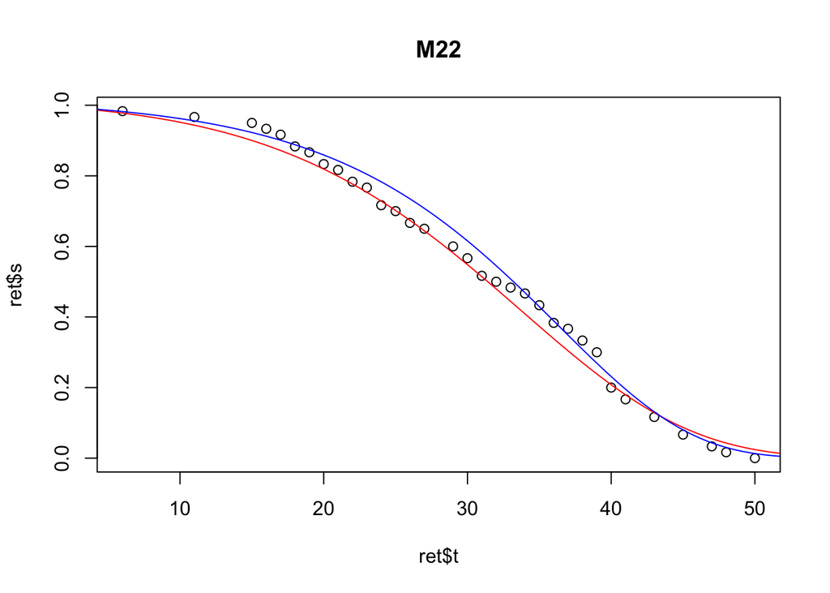

```
##   my.strains samplesize           R       t0        n         G
## 6        M22         60 0.002509604 64.81929 9.400784 0.1296031
##   longfilename    avgLS    stdLS        CV GompGFlex   GompRFlex
## 6  rls/M22.csv 31.83333 10.27118 0.3226549 0.1077899 0.002145453
##   GompLogLikFlex GompAICFlex WeibShapeFlex WeibRateFlex WeibLogLikFlex
## 6         -222.9         450      3.596392     35.37118         -223.9
##   WeibAICFlex BinomialAIC
## 6         452    453.6004
##             R       t0        n         G
## 6 0.002509604 64.81929 9.400784 0.1296031
```

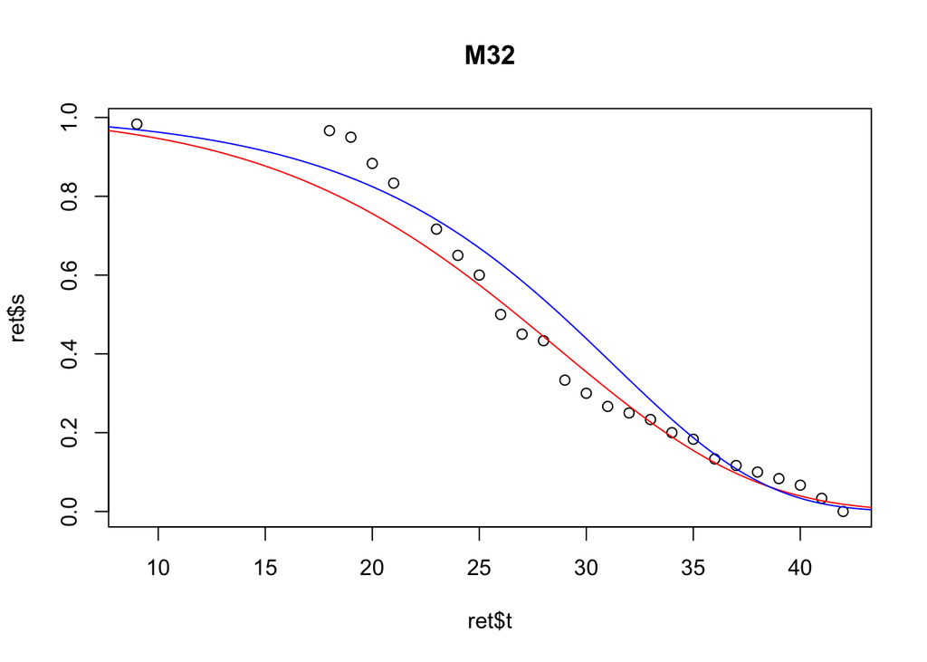

```
##   my.strains samplesize           R       t0       n         G
## 7        M32         60 0.002209031 49.67204 9.55655 0.1722609
##   longfilename    avgLS    stdLS        CV GompGFlex   GompRFlex
## 7  rls/M32.csv 27.96667 6.888868 0.2463242 0.1404328 0.001738458
##   GompLogLikFlex GompAICFlex WeibShapeFlex WeibRateFlex WeibLogLikFlex
## 7         -205.6         415      4.419104     30.62828         -201.4
##   WeibAICFlex BinomialAIC
## 7         407    417.9426
##             R       t0       n         G
## 7 0.002209031 49.67204 9.55655 0.1722609
```

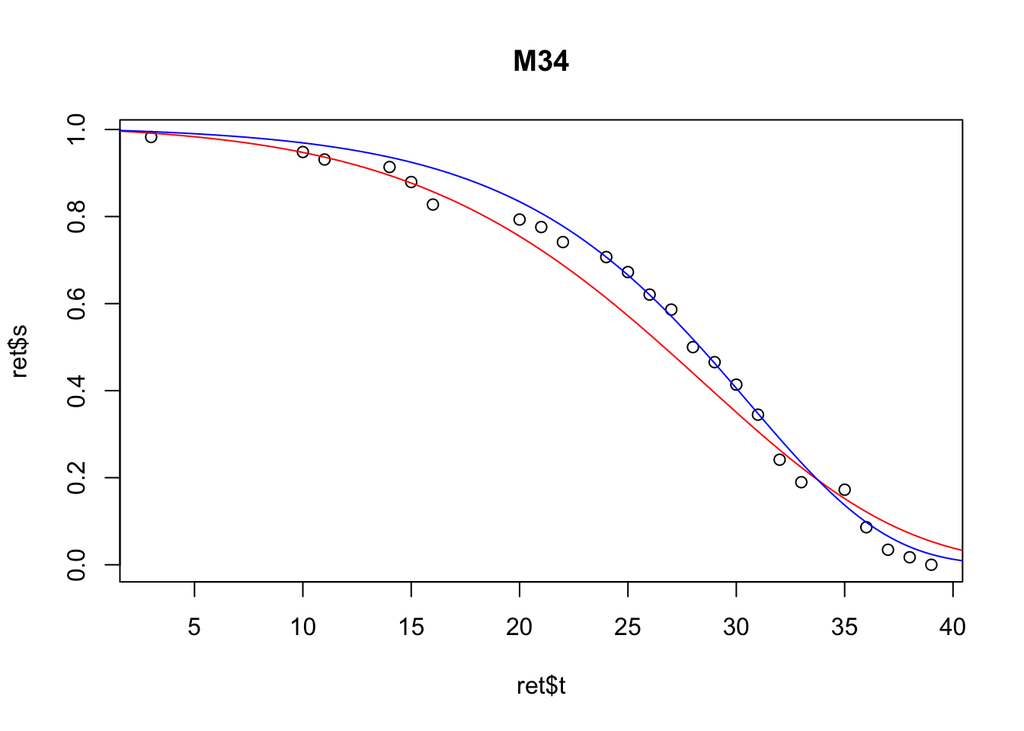

```
##   my.strains samplesize           R       t0        n         G
## 8        M34         58 0.002123117 44.49124 8.940977 0.1784841
##   longfilename    avgLS   stdLS        CV GompGFlex   GompRFlex
## 8  rls/M34.csv 27.01724 8.20674 0.3037593  0.156928 0.001289647
##   GompLogLikFlex GompAICFlex WeibShapeFlex WeibRateFlex WeibLogLikFlex
## 8           -198         400      3.985745     29.77062         -203.7
##   WeibAICFlex BinomialAIC
## 8         411    408.2894
##             R       t0        n         G
## 8 0.002123117 44.49124 8.940977 0.1784841
```

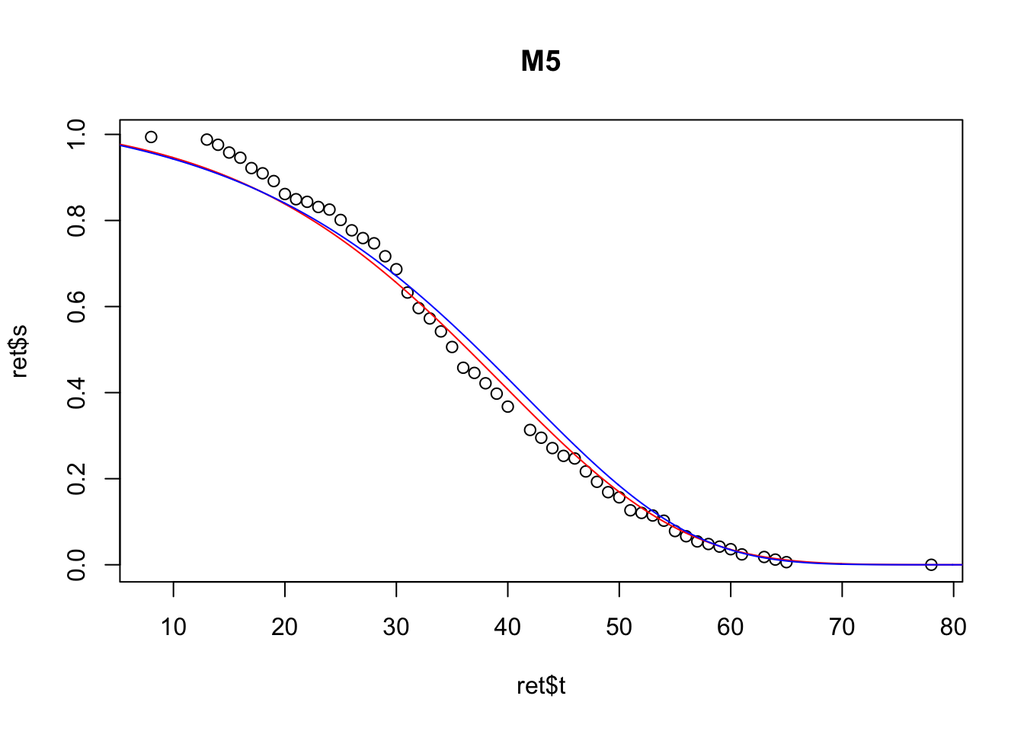

```
##   my.strains samplesize          R       t0        n          G
## 9         M5        166 0.00358755 104.6057 9.903523 0.08511506
##   longfilename    avgLS    stdLS        CV  GompGFlex  GompRFlex
## 9   rls/M5.csv 36.62651 12.93875 0.3532618 0.06684902 0.00414725
##   GompLogLikFlex GompAICFlex WeibShapeFlex WeibRateFlex WeibLogLikFlex
## 9         -670.1        1344      3.098392     40.98709         -658.3
##   WeibAICFlex BinomialAIC
## 9        1321    1339.875
##            R       t0        n          G
## 9 0.00358755 104.6057 9.903523 0.08511506
```

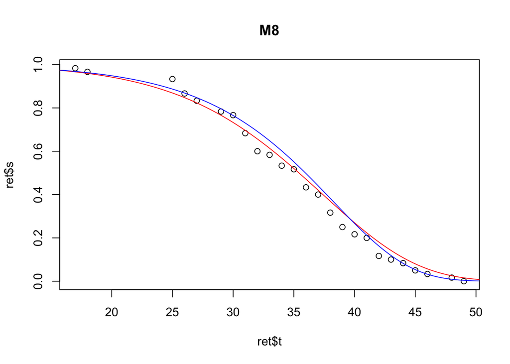

```
##    my.strains samplesize            R       t0    n         G longfilename
## 10         M8         60 0.0002276221 45.20362 11.5 0.2322823   rls/M8.csv
##       avgLS    stdLS        CV GompGFlex    GompRFlex GompLogLikFlex
## 10 34.93333 6.905823 0.1976858 0.1588883 0.0003653141         -201.9
##    GompAICFlex WeibShapeFlex WeibRateFlex WeibLogLikFlex WeibAICFlex
## 10         408      5.872213     37.70008         -200.1         404
##    BinomialAIC
## 10    409.6617
##               R       t0    n         G
## 10 0.0002276221 45.20362 11.5 0.2322823
```

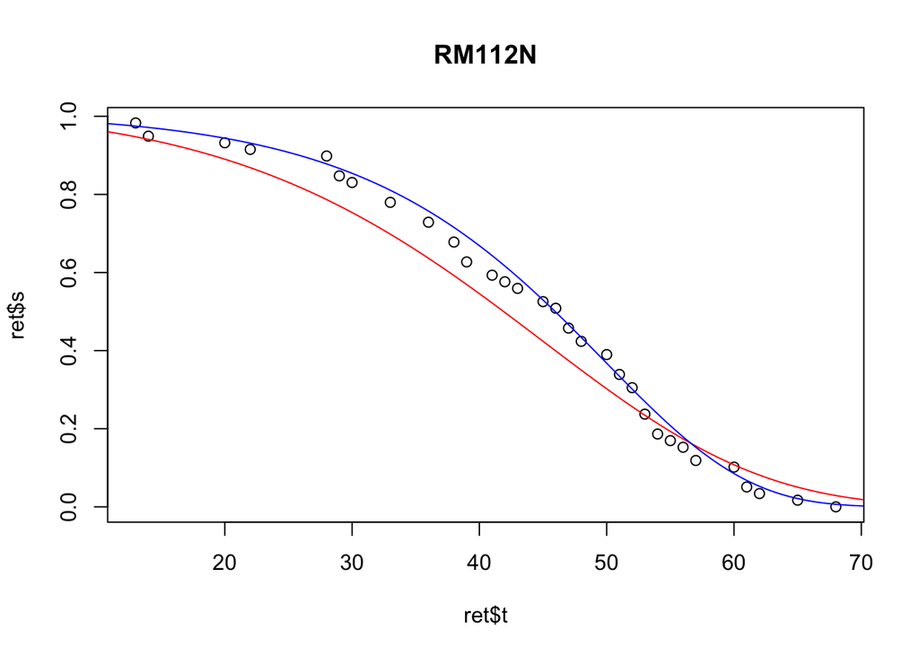

```
##    my.strains samplesize           R       t0        n          G
## 11     RM112N         59 0.002236752 78.29925 8.184119 0.09175208
##      longfilename   avgLS    stdLS        CV  GompGFlex  GompRFlex
## 11 rls/RM112N.csv 44.0678 13.00645 0.2951464 0.08938574 0.00103633
##    GompLogLikFlex GompAICFlex WeibShapeFlex WeibRateFlex WeibLogLikFlex
## 11           -232         468      4.038465     48.63895         -233.7
##    WeibAICFlex BinomialAIC
## 11         471     478.043
##              R       t0        n          G
## 11 0.002236752 78.29925 8.184119 0.09175208
```

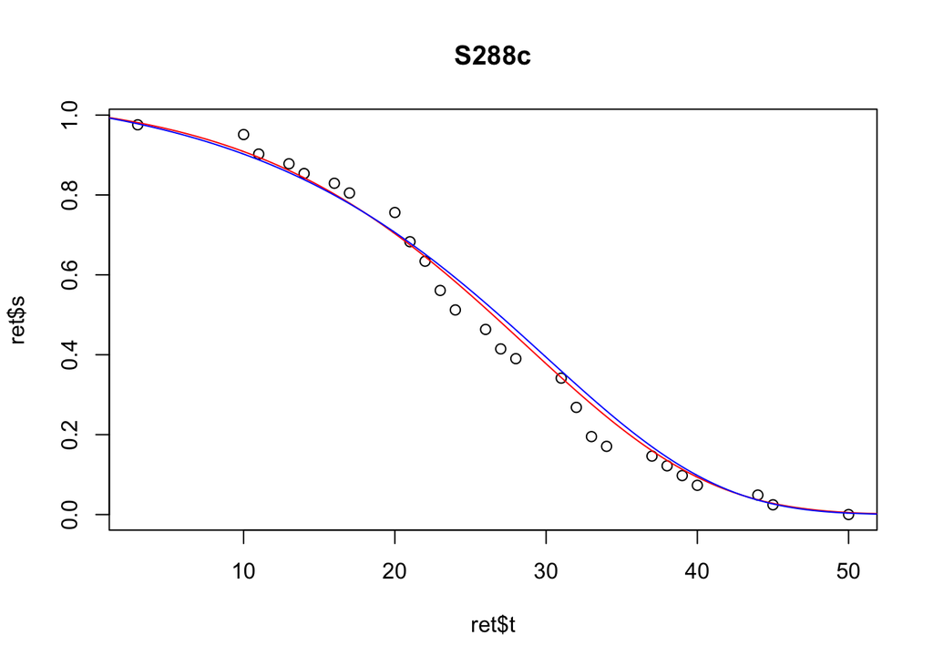

```
##    my.strains samplesize           R       t0        n         G
## 12      S288c         41 0.005361188 80.43622 9.959994 0.1113925
##     longfilename    avgLS    stdLS       CV  GompGFlex   GompRFlex
## 12 rls/S288c.csv 26.26829 10.25433 0.390369 0.08686882 0.006451205
##    GompLogLikFlex GompAICFlex WeibShapeFlex WeibRateFlex WeibLogLikFlex
## 12         -154.2         312      2.792964     29.42942         -153.3
##    WeibAICFlex BinomialAIC
## 12         311    313.4152
##              R       t0        n         G
## 12 0.005361188 80.43622 9.959994 0.1113925
```

[3 more figures not shown]

```
##    my.strains samplesize           R       t0        n         G
## 15     YPS163        130 0.001915118 52.24318 8.437491 0.1423629
##      longfilename    avgLS    stdLS        CV GompGFlex    GompRFlex
## 15 rls/YPS163.csv 34.43077 8.591449 0.2495282 0.1338728 0.0007889455
##    GompLogLikFlex GompAICFlex WeibShapeFlex WeibRateFlex WeibLogLikFlex
## 15         -459.6         923      4.825655     37.62671         -460.2
##    WeibAICFlex BinomialAIC
## 15         924    946.1981
##              R       t0        n         G
## 15 0.001915118 52.24318 8.437491 0.1423629
```

```r
for( i in 1:length(my.strains)){
#for( i in 3:4){
  filename = paste("rls/", my.strains[i], ".csv", sep='' );
  tb = read.csv( filename, header =F)

  ret = calculate.s(tb[,1])
  plot( ret$s ~ ret$t, main=my.strains[i]);
  print (report[i,  ]);

  #overlay binomial aging viability
  print (report[i, c("R", "t0", "n", "G")] );
  t = seq(0,max(ret$t*1.1), 0.1);
  # s = exp( (R t0/n)*(1 - (1+t/t0)^n ) )
  s = exp( (report$R[i]* report$t0[i]/report$n[i])*(1 - (1+t/report$t0[i])^report$n[i] ) ) ;
  lines(s ~ t, col='red')

  #overlay gompertz  viability
  s.g =  G.s( c(report$GompRFlex[i], report$GompGFlex[i], 0), t )
  lines(s.g ~ t, col='blue')
 }
```

# show the report

```r
report
```

```
##    my.strains samplesize            R        t0         n          G
## 1        101S         85 0.0019760147  52.08681  9.174228 0.15693470
## 2        M1-2         54 0.0027664362  56.71641  9.475570 0.14943770
## 3         M13         70 0.0030071379  56.81672  9.648416 0.15221605
## 4         M14         60 0.0024869119  76.42752  9.180570 0.10703698
## 5        M2-8        105 0.0036633868  60.10209 10.068263 0.15088099
## 6         M22         60 0.0025096036  64.81929  9.400784 0.12960313
## 7         M32         60 0.0022090312  49.67204  9.556550 0.17226088
## 8         M34         58 0.0021231171  44.49124  8.940977 0.17848407
## 9          M5        166 0.0035875496 104.60572  9.903523 0.08511506
## 10         M8         60 0.0002276221  45.20362 11.500000 0.23228229
## 11     RM112N         59 0.0022367518  78.29925  8.184119 0.09175208
## 12      S288c         41 0.0053611878  80.43622  9.959994 0.11139252
## 13      SGU57         58 0.0067256427  78.02415  9.696555 0.11145978
## 14     YPS128         69 0.0024378049  58.96767  8.260993 0.12313514
```

[output cut: 49 more lines]

Calculate lambda based on t0 = (1-p)/(p Lambda) So, 1/lambda = t0 * p / (1-p)

```r
p = 0.7
report$One.over.lambdaP07 = report$t0 * p/ (1-p)
report[, c("t0", "One.over.lambdaP07")]
```

```
##           t0 One.over.lambdaP07
## 1   52.08681           121.5359
## 2   56.71641           132.3383
## 3   56.81672           132.5723
## 4   76.42752           178.3309
## 5   60.10209           140.2382
## 6   64.81929           151.2450
## 7   49.67204           115.9014
## 8   44.49124           103.8129
## 9  104.60572           244.0800
## 10  45.20362           105.4751
## 11  78.29925           182.6982
## 12  80.43622           187.6845
## 13  78.02415           182.0564
## 14  58.96767           137.5912
## 15  52.24318           121.9008
```

```r
summary( report[, c("t0", "One.over.lambdaP07")])
```

```
##        t0         One.over.lambdaP07
##  Min.   : 44.49   Min.   :103.8
##  1st Qu.: 52.16   1st Qu.:121.7
##  Median : 58.97   Median :137.6
##  Mean   : 63.93   Mean   :149.2
##  3rd Qu.: 77.23   3rd Qu.:180.2
##  Max.   :104.61   Max.   :244.1
```

Histogram of 1/lambda for p=0.7

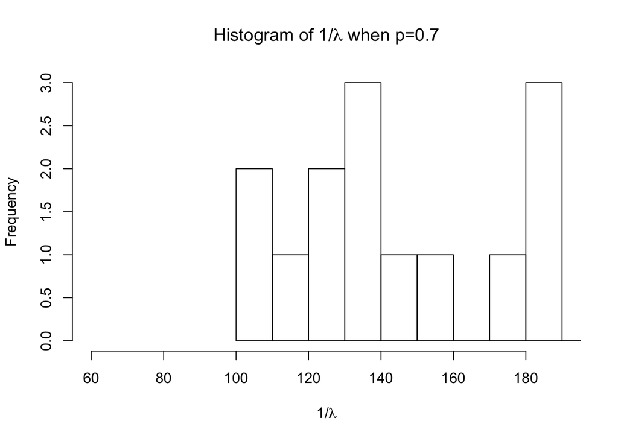

```r
hist(report$One.over.lambdaP07, br=20, xlim=c(60,190), xlab=expression(paste("1/",lambda) ), main=expression(paste("Histogram of 1/",lambda, " when p=0.7")))
```

```r
p = 0.9
report$One.over.lambdaP09 = report$t0 * p/ (1-p)
report[, c("t0", "One.over.lambdaP09")]
```

```
##           t0 One.over.lambdaP09
## 1   52.08681           468.7813
## 2   56.71641           510.4477
## 3   56.81672           511.3504
## 4   76.42752           687.8476
## 5   60.10209           540.9188
## 6   64.81929           583.3737
## 7   49.67204           447.0484
## 8   44.49124           400.4211
## 9  104.60572           941.4515
## 10  45.20362           406.8326
## 11  78.29925           704.6932
## 12  80.43622           723.9260
## 13  78.02415           702.2174
## 14  58.96767           530.7091
## 15  52.24318           470.1886
```

```r
summary( report[, c("t0", "One.over.lambdaP09")] )
```

```
##        t0         One.over.lambdaP09
##  Min.   : 44.49   Min.   :400.4
##  1st Qu.: 52.16   1st Qu.:469.5
##  Median : 58.97   Median :530.7
##  Mean   : 63.93   Mean   :575.3
##  3rd Qu.: 77.23   3rd Qu.:695.0
##  Max.   :104.61   Max.   :941.5
```

Histogram 1/lambda, p=0.9

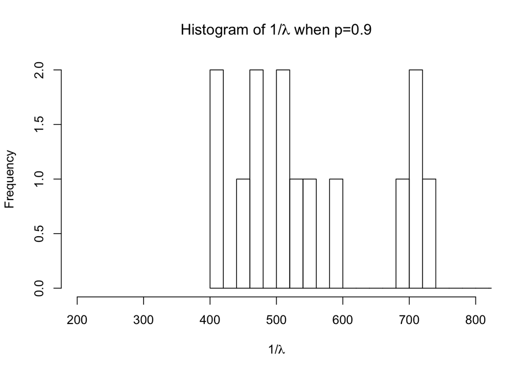

```r
hist(report$One.over.lambdaP09, br=20, xlim=c(200,800), xlab=expression(paste("1/",lambda) ), main=expression(paste("Histogram of 1/",lambda, " when p=0.9")))
```

# Explorative analysis

```r
# my.strains=c("101S", "BY4743","M1-2","M13","M14","M2-8","M22","M32","M34","M5","M8","RM112N","S288c","SGU57","SK1","W303","YPS128","YPS163")

#my.strains=c("101S", "M1-2","M13","M14","M2-8","M22","M32","M34","M5","M8","RM112N","S288c","SGU57", "YPS128","YPS163")
report2 = report
summary(lm(log10(report2$GompRFlex) ~ report2$GompGFlex))
```

```
##
## Call:
## lm(formula = log10(report2$GompRFlex) ~ report2$GompGFlex)
##
## Residuals:
##      Min       1Q   Median       3Q      Max
## -0.50796 -0.22010 -0.03155  0.20504  0.36320
##
## Coefficients:
##                   Estimate Std. Error t value Pr(>|t|)
## (Intercept)        -1.6976     0.3278  -5.179 0.000177 ***
## report2$GompGFlex  -8.7148     2.7614  -3.156 0.007585 **
## ---
## Signif. codes:  0 '***' 0.001 '**' 0.01 '*' 0.05 '.' 0.1 ' ' 1
##
## Residual standard error: 0.2789 on 13 degrees of freedom
## Multiple R-squared:  0.4338, Adjusted R-squared:  0.3902
## F-statistic:  9.96 on 1 and 13 DF,  p-value: 0.007585
```

```r
summary(lm(log10(report2$R) ~ report2$GompGFlex))
```

```
##
## Call:
## lm(formula = log10(report2$R) ~ report2$GompGFlex)
##
## Residuals:
##      Min       1Q   Median       3Q      Max
## -0.68974 -0.11029  0.05577  0.15224  0.26476
##
## Coefficients:
##                   Estimate Std. Error t value Pr(>|t|)
## (Intercept)        -1.7169     0.3007  -5.710 7.18e-05 ***
## report2$GompGFlex  -7.7799     2.5335  -3.071  0.00893 **
## ---
## Signif. codes:  0 '***' 0.001 '**' 0.01 '*' 0.05 '.' 0.1 ' ' 1
##
## Residual standard error: 0.2559 on 13 degrees of freedom
## Multiple R-squared:  0.4204, Adjusted R-squared:  0.3758
## F-statistic:  9.43 on 1 and 13 DF,  p-value: 0.008935
```

```r
summary(lm(log10(report2$R) ~ report2$G)) #G from t0 and n
```

```
##
## Call:
## lm(formula = log10(report2$R) ~ report2$G)
##
## Residuals:
##      Min       1Q   Median       3Q      Max
## -0.43986 -0.13556  0.02285  0.17206  0.26760
##
## Coefficients:
##             Estimate Std. Error t value Pr(>|t|)
## (Intercept)  -1.7359     0.2302  -7.543 4.23e-06 ***
## report2$G    -6.3156     1.5944  -3.961  0.00163 **
## ---
## Signif. codes:  0 '***' 0.001 '**' 0.01 '*' 0.05 '.' 0.1 ' ' 1
##
## Residual standard error: 0.2262 on 13 degrees of freedom
## Multiple R-squared:  0.5469, Adjusted R-squared:  0.512
## F-statistic: 15.69 on 1 and 13 DF,  p-value: 0.001627
```

```r
summary(lm(report2$GompGFlex ~ report2$G)) #good agreement bwteen GFlex and G from binomial modeling
```

```
##
## Call:
## lm(formula = report2$GompGFlex ~ report2$G)
##
## Residuals:
##       Min        1Q    Median        3Q       Max
## -0.017814 -0.007406 -0.001218  0.005985  0.016283
##
## Coefficients:
##             Estimate Std. Error t value Pr(>|t|)
## (Intercept)  0.02400    0.01092   2.198   0.0467 *
## report2$G    0.65739    0.07566   8.689 8.95e-07 ***
## ---
## Signif. codes:  0 '***' 0.001 '**' 0.01 '*' 0.05 '.' 0.1 ' ' 1
##
## Residual standard error: 0.01074 on 13 degrees of freedom
## Multiple R-squared:  0.8531, Adjusted R-squared:  0.8418
## F-statistic: 75.49 on 1 and 13 DF,  p-value: 8.954e-07
```

```r
summary(lm(log10(report2$R) ~ report2$t0)) #G from t0 and n
```

```
##
## Call:
## lm(formula = log10(report2$R) ~ report2$t0)
##
## Residuals:
##      Min       1Q   Median       3Q      Max
## -0.83042 -0.05424  0.05629  0.15827  0.29893
##
## Coefficients:
##              Estimate Std. Error t value Pr(>|t|)
## (Intercept) -3.282258   0.302783 -10.840    7e-08 ***
## report2$t0   0.010395   0.004595   2.262   0.0414 *
## ---
## Signif. codes:  0 '***' 0.001 '**' 0.01 '*' 0.05 '.' 0.1 ' ' 1
##
## Residual standard error: 0.2847 on 13 degrees of freedom
## Multiple R-squared:  0.2825, Adjusted R-squared:  0.2273
## F-statistic: 5.119 on 1 and 13 DF,  p-value: 0.04145
```

```r
summary(lm(log10(report2$R) ~ report2$n)) #G from t0 and n
```

```
##
## Call:
## lm(formula = log10(report2$R) ~ report2$n)
##
## Residuals:
##      Min       1Q   Median       3Q      Max
## -0.71779 -0.14748 -0.01871  0.18607  0.48557
##
## Coefficients:
##             Estimate Std. Error t value Pr(>|t|)
## (Intercept)  -1.2214     0.9494  -1.286    0.221
## report2$n    -0.1481     0.1004  -1.476    0.164
##
## Residual standard error: 0.3111 on 13 degrees of freedom
## Multiple R-squared:  0.1435, Adjusted R-squared:  0.07765
## F-statistic: 2.179 on 1 and 13 DF,  p-value: 0.1637
```